# BIOS/CPH685 Homework 3

Due Nov 27 @ 11:59PM

# Learn by doing

I found the [TensorFlow for R Blog](https://blogs.rstudio.com/tensorflow/) series at RStudio quite illuminating. Choose one blog related with deep learning architeture that interests you and do following.

# Question 1

Reproduce the results in the blog and write a tutorial as a `Rmd` and `html` file to report your results.

## Modeling censored data with tfprobability (July 30, 2019)

You may click the web [link](https://blogs.rstudio.com/tensorflow/posts/2019-07-31-censored-data/) to see the details.

In this section, I will reproduce this task.  
In this post we use tfprobability, the R interface to TensorFlow Probability, to model censored data. Again, the exposition is inspired by the treatment of this topic in Richard McElreath’s Statistical Rethinking. Instead of cute cats though, we model immaterial entities from the cold world of technology: This post explores durations of CRAN package checks, a dataset that comes with Max Kuhn’s parsnip.

The following code works with the current stable releases of TensorFlow and TensorFlow Probability, which are 1.14 and 0.7, respectively. If you don’t have tfprobability installed, get it from Github:

**However, Before you install tfprobability package, you need to update tensorflow package to 2.0.0, because, tfprobability package need at least 2.0.0 version of tensorflow.**

```r
require(remotes)
remotes::install_github("rstudio/tfprobability")
```

```r
library(keras)
use_implementation("tensorflow")
library(tensorflow)
library(tfprobability)
library(parsnip)
library(tidyverse)
library(zeallot)
library(gridExtra)
library(HDInterval)
library(tidymodels)
library(survival)
library(kableExtra)
library(xtable)
```

```r
tf$compat$v1$enable_v2_behavior()
```

Besides the check durations we want to model, check_times reports various features of the package in question, such as number of imported packages, number of dependencies, size of code and documentation files, etc. The status variable indicates whether the check completed or errored out.

```r
df <- check_times %>% select(-package)
glimpse(df)
```

```
## Observations: 13,626
## Variables: 24
## $ authors        <int> 1, 1, 1, 1, 5, 3, 2, 1, 4, 6, 1, 2, 1, 1, 1, 1, 1…
## $ imports        <dbl> 0, 6, 0, 0, 3, 1, 0, 4, 0, 7, 0, 0, 0, 0, 3, 2, 1…
## $ suggests       <dbl> 2, 4, 0, 0, 2, 0, 2, 2, 0, 0, 2, 8, 0, 0, 2, 0, 1…
## $ depends        <dbl> 3, 1, 6, 1, 1, 1, 5, 0, 1, 1, 6, 5, 0, 0, 0, 1, 1…
## $ Roxygen        <dbl> 0, 1, 0, 0, 1, 0, 0, 1, 0, 0, 1, 0, 1, 0, 1, 0, 1…
## $ gh             <dbl> 0, 1, 0, 0, 0, 0, 0, 1, 0, 0, 1, 0, 0, 0, 1, 0, 1…
## $ rforge         <dbl> 0, 0, 0, 0, 0, 0, 0, 0, 0, 0, 0, 0, 0, 0, 0, 0, 0…
## $ descr          <int> 217, 313, 269, 63, 223, 1031, 135, 344, 204, 335,…
## $ r_count        <int> 2, 20, 8, 0, 10, 10, 16, 3, 6, 14, 16, 4, 1, 1, 1…
## $ r_size         <dbl> 0.029053, 0.046336, 0.078374, 0.000000, 0.019080,…
## $ ns_import      <dbl> 3, 15, 6, 0, 4, 5, 0, 4, 2, 10, 5, 6, 1, 0, 2, 2,…
## $ ns_export      <dbl> 0, 19, 0, 0, 10, 0, 0, 2, 0, 9, 3, 4, 0, 1, 10, 0…
## $ s3_methods     <dbl> 3, 0, 11, 0, 0, 0, 0, 2, 0, 23, 0, 0, 2, 5, 0, 4,…
## $ s4_methods     <dbl> 0, 0, 0, 0, 0, 0, 0, 0, 0, 0, 0, 0, 0, 0, 0, 0, 0…
## $ doc_count      <int> 0, 3, 1, 0, 1, 0, 0, 0, 0, 0, 0, 0, 0, 0, 1, 0, 0…
## $ doc_size       <dbl> 0.000000, 0.019757, 0.038281, 0.000000, 0.007874,…
## $ src_count      <int> 0, 0, 0, 0, 0, 0, 0, 2, 0, 5, 3, 0, 0, 0, 0, 0, 0…
## $ src_size       <dbl> 0.000000, 0.000000, 0.000000, 0.000000, 0.000000,…
## $ data_count     <int> 2, 0, 0, 3, 3, 1, 10, 0, 4, 2, 2, 146, 0, 0, 0, 0…
## $ data_size      <dbl> 0.025292, 0.000000, 0.000000, 4.885864, 4.595504,…
## $ testthat_count <int> 0, 8, 0, 0, 0, 0, 0, 1, 0, 0, 0, 0, 0, 0, 0, 0, 3…
## $ testthat_size  <dbl> 0.000000, 0.002496, 0.000000, 0.000000, 0.000000,…
## $ check_time     <dbl> 49, 101, 292, 21, 103, 46, 78, 91, 47, 196, 200, …
## $ status         <dbl> 1, 1, 1, 1, 1, 1, 1, 1, 1, 1, 1, 1, 1, 1, 1, 1, 1…
```

Of these 13,626 observations, just 103 are censored:

```r
table(df$status)
```

```
##
##     0     1
##   103 13523
```

For better readability, we’ll work with a subset of the columns. We use surv_reg to help us find a useful and interesting subset of predictors:

When I run the code below, It said *engine ‘survreg’ is not availble. Please use one of: ‘flexsurv’, ‘survival’*.

```r
survreg_fit <-
  surv_reg(dist = "exponential") %>%
  set_engine("survreg") %>%
  fit(Surv(check_time, status) ~ .,
      data = df)
tidy(survreg_fit)
```

So I changed *survreg* to *survival*. The results are the same.

```r
survreg_fit <-
  surv_reg(dist = "exponential") %>%
  set_engine("survival") %>%
  fit(Surv(check_time, status) ~ .,
      data = df)

kable(as.data.frame(tidy(survreg_fit)), booktabs=TRUE) %>%
  kable_styling(position = "center")
```

| term | estimate | std.error | statistic | p.value | conf.low | conf.high |
| --- | --- | --- | --- | --- | --- | --- |
| (Intercept) | 3.8616324 | 0.0219348 | 176.0501425 | 0.0000000 | NA | NA |
| authors | 0.0138976 | 0.0057987 | 2.3966645 | 0.0165451 | NA | NA |
| imports | 0.0605994 | 0.0029017 | 20.8839748 | 0.0000000 | NA | NA |
| suggests | 0.0331681 | 0.0035750 | 9.2777156 | 0.0000000 | NA | NA |
| depends | 0.1176575 | 0.0061737 | 19.0578457 | 0.0000000 | NA | NA |
| Roxygen | 0.0701550 | 0.0208966 | 3.3572488 | 0.0007872 | NA | NA |
| gh | 0.0089773 | 0.0217079 | 0.4135513 | 0.6792028 | NA | NA |
| rforge | 0.0232050 | 0.0661972 | 0.3505439 | 0.7259306 | NA | NA |
| descr | 0.0001379 | 0.0000337 | 4.0972091 | 0.0000418 | NA | NA |
| r_count | 0.0020872 | 0.0005250 | 3.9753923 | 0.0000703 | NA | NA |
| r_size | 0.4809423 | 0.0818931 | 5.8728048 | 0.0000000 | NA | NA |
| ns_import | 0.0035235 | 0.0008965 | 3.9303626 | 0.0000848 | NA | NA |
| ns_export | -0.0016144 | 0.0003079 | -5.2439053 | 0.0000002 | NA | NA |
| s3_methods | 0.0004485 | 0.0004213 | 1.0645612 | 0.2870745 | NA | NA |
| s4_methods | -0.0015354 | 0.0020615 | -0.7447709 | 0.4564102 | NA | NA |
| doc_count | 0.0738522 | 0.0116659 | 6.3306189 | 0.0000000 | NA | NA |
| doc_size | 2.8632838 | 0.5171562 | 5.5365939 | 0.0000000 | NA | NA |
| src_count | 0.0121591 | 0.0012696 | 9.5773595 | 0.0000000 | NA | NA |
| src_size | -0.0241712 | 0.0181013 | -1.3353295 | 0.1817685 | NA | NA |
| data_count | 0.0000415 | 0.0009802 | 0.0422910 | 0.9662667 | NA | NA |
| data_size | 0.0217115 | 0.0135237 | 1.6054371 | 0.1083976 | NA | NA |
| testthat_count | -0.0001276 | 0.0012658 | -0.1008243 | 0.9196899 | NA | NA |
| testthat_size | 0.0107827 | 0.0139369 | 0.7736831 | 0.4391182 | NA | NA |

It seems that if we choose imports, depends, r_size, doc_size, ns_import and ns_export we end up with a mix of (comparatively) powerful predictors from different semantic spaces and of different scales.

Before pruning the dataframe, we save away the target variable. In our model and training setup, it is convenient to have censored and uncensored data stored separately, so here we create two target matrices instead of one:

```r
# check times for failed checks
# _c stands for censored
check_time_c <- df %>%
  filter(status == 0) %>%
  select(check_time) %>%
  as.matrix()

# check times for successful checks
check_time_nc <- df %>%
  filter(status == 1) %>%
  select(check_time) %>%
  as.matrix()
```

Now we can zoom in on the variables of interest, setting up one dataframe for the censored data and one for the uncensored data each. All predictors are normalized to avoid overflow during sampling. 1 We add a column of 1s for use as an intercept.

```r
df1 <- df %>% select(status,
                    depends,
                    imports,
                    doc_size,
                    r_size,
                    ns_import,
                    ns_export) %>%
  mutate_at(.vars = 2:7, .funs = function(x) (x - min(x))/(max(x)-min(x))) %>%
  add_column(intercept = rep(1, nrow(df)), .before = 1)

# dataframe of predictors for censored data
df_c <- df1 %>% filter(status == 0) %>% select(-status)
# dataframe of predictors for non-censored data
df_nc <- df1 %>% filter(status == 1) %>% select(-status)
```

### The results

#### check time

```r
ct_c <- round(quantile(check_time_c,
                       probs = c(0.1, 0.3, 0.5, 0.7, 0.9, 1.0)))
ct_nc <- round(quantile(check_time_nc,
                       probs = c(0.1, 0.3, 0.5, 0.7, 0.9, 1.0)))
res_ct <- data.frame(Completed = ct_c, Not_Completed = ct_nc)

kable(t(res_ct), booktabs=TRUE) %>%
  kable_styling(position = "center")
```

|  | 10% | 30% | 50% | 70% | 90% | 100% |
| --- | --- | --- | --- | --- | --- | --- |
| Completed | 42 | 71 | 97 | 143 | 294 | 696 |
| Not_Completed | 36 | 55 | 79 | 115 | 211 | 1343 |

Here and in the following tables, we report the unnormalized, original values as contained in check_times.

```r
df_unnormalized <- df %>% select(status,
                    depends,
                    imports,
                    doc_size,
                    r_size,
                    ns_import,
                    ns_export)
# dataframe of predictors for censored data
df_c_unnormalized <- df_unnormalized %>% filter(status == 0) %>% select(-status)
# dataframe of predictors for non-censored data
df_nc_unnormalized <- df_unnormalized %>% filter(status == 1) %>% select(-status)
```

#### depends

```r
depends_c <- round(quantile(df_c_unnormalized$depends,
                       probs = c(0.1, 0.3, 0.5, 0.7, 0.9, 1.0)))
depends_nc <- round(quantile(df_nc_unnormalized$depends,
                       probs = c(0.1, 0.3, 0.5, 0.7, 0.9, 1.0)))
res_depends <- data.frame(Completed = depends_c, Not_Completed = depends_nc)

kable(t(res_depends), booktabs=TRUE) %>%
  kable_styling(position = "center")
```

|  | 10% | 30% | 50% | 70% | 90% | 100% |
| --- | --- | --- | --- | --- | --- | --- |
| Completed | 0 | 1 | 1 | 2 | 4 | 7 |
| Not_Completed | 0 | 1 | 1 | 2 | 4 | 12 |

#### imports

```r
imports_c <- round(quantile(df_c_unnormalized$imports,
                       probs = c(0.1, 0.3, 0.5, 0.7, 0.9, 1.0)))
imports_nc <- round(quantile(df_nc_unnormalized$imports,
                       probs = c(0.1, 0.3, 0.5, 0.7, 0.9, 1.0)))
res_imports <- data.frame(Completed = imports_c, Not_Completed = imports_nc)

kable(t(res_imports), booktabs=TRUE) %>%
  kable_styling(position = "center")
```

|  | 10% | 30% | 50% | 70% | 90% | 100% |
| --- | --- | --- | --- | --- | --- | --- |
| Completed | 0 | 2 | 5 | 8 | 12 | 22 |
| Not_Completed | 0 | 0 | 2 | 4 | 9 | 43 |

#### ns_export

```r
ns_export_c <- round(quantile(df_c_unnormalized$ns_export,
                       probs = c(0.1, 0.3, 0.5, 0.7, 0.9, 1.0)))
ns_export_nc <- round(quantile(df_nc_unnormalized$ns_export,
                       probs = c(0.1, 0.3, 0.5, 0.7, 0.9, 1.0)))
res_ns_export <- data.frame(Completed = ns_export_c,
                            Not_Completed = ns_export_nc)

kable(t(res_ns_export), booktabs=TRUE) %>%
  kable_styling(position = "center")
```

|  | 10% | 30% | 50% | 70% | 90% | 100% |
| --- | --- | --- | --- | --- | --- | --- |
| Completed | 0 | 1 | 5 | 13 | 34 | 336 |
| Not_Completed | 0 | 1 | 2 | 8 | 26 | 2547 |

#### ns_import

```r
ns_import_c <- round(quantile(df_c_unnormalized$ns_import,
                       probs = c(0.1, 0.3, 0.5, 0.7, 0.9, 1.0)))
ns_import_nc <- round(quantile(df_nc_unnormalized$ns_import,
                       probs = c(0.1, 0.3, 0.5, 0.7, 0.9, 1.0)))
res_ns_import <- data.frame(Completed = ns_import_c,
                            Not_Completed = ns_import_nc)

kable(t(res_ns_import), booktabs=TRUE) %>%
  kable_styling(position = "center")
```

|  | 10% | 30% | 50% | 70% | 90% | 100% |
| --- | --- | --- | --- | --- | --- | --- |
| Completed | 0 | 2 | 5 | 11 | 23 | 297 |
| Not_Completed | 0 | 1 | 3 | 6 | 19 | 312 |

#### r_size

```r
r_size_c <- round(quantile(df_c_unnormalized$r_size,
                       probs = c(0.1, 0.3, 0.5, 0.7, 0.9, 1.0)))
r_size_nc <- round(quantile(df_nc_unnormalized$r_size,
                       probs = c(0.1, 0.3, 0.5, 0.7, 0.9, 1.0)))
res_r_size <- data.frame(Completed = r_size_c,
                            Not_Completed = r_size_nc)

kable(t(res_r_size), booktabs=TRUE) %>%
  kable_styling(position = "center")
```

|  | 10% | 30% | 50% | 70% | 90% | 100% |
| --- | --- | --- | --- | --- | --- | --- |
| Completed | 0 | 0 | 0 | 0 | 0 | 2 |
| Not_Completed | 0 | 0 | 0 | 0 | 0 | 4 |

#### doc_size

```r
doc_size_c <- quantile(df_c_unnormalized$doc_size,
                       probs = c(0.1, 0.3, 0.5, 0.7, 0.9, 1.0))
doc_size_nc <- quantile(df_nc_unnormalized$doc_size,
                       probs = c(0.1, 0.3, 0.5, 0.7, 0.9, 1.0))
res_doc_size <- data.frame(Completed = doc_size_c,
                            Not_Completed = doc_size_nc)

kable(t(res_doc_size), booktabs=TRUE) %>%
  kable_styling(position = "center")
```

|  | 10% | 30% | 50% | 70% | 90% | 100% |
| --- | --- | --- | --- | --- | --- | --- |
| Completed | 0 | 0 | 0 | 0.0114582 | 0.0424174 | 0.114431 |
| Not_Completed | 0 | 0 | 0 | 0.0003822 | 0.0233988 | 0.988959 |

### The model

As for the latter, we use 0-centered, Gaussian priors for all parameters. Standard deviations of 1 turned out to work well. As the priors are all the same, instead of listing a bunch of tfd_normals, we can create them all at once as

```r
library(keras)
use_implementation("tensorflow")
model <- function(data) {
  tfd_joint_distribution_sequential(
    list(
      tfd_sample_distribution(tfd_normal(0, 1), sample_shape = 7),
      function(betas)
        tfd_independent(
          tfd_exponential(
            rate = 1 / tf$math$exp(tf$transpose(
              tf$matmul(tf$cast(data, betas$dtype), tf$transpose(betas))))),
          reinterpreted_batch_ndims = 1)))
}
m <- model(df_nc %>% as.matrix())
```

Always, we test if samples from that model have the expected shapes:

```r
samples <- m %>% tfd_sample(2)
```

How likely are these samples?

```r
m %>% tfd_log_prob(samples)
```

The next thing to do is define the target we want to optimize.

### Optimization Target

```r
get_exponential_lccdf <- function(betas, data, target) {
  e <-  tfd_independent(tfd_exponential(rate = 1 / tf$math$exp(tf$transpose(tf$matmul(
    tf$cast(data, betas$dtype), tf$transpose(betas)
  )))),
  reinterpreted_batch_ndims = 1)
  cum_prob <- e %>% tfd_cdf(tf$cast(target, betas$dtype))
  tf$math$log(1 - cum_prob)
}

get_log_prob <-
  function(target_nc,
           censored_data = NULL,
           target_c = NULL) {
    log_prob <- function(betas) {
      log_prob <-
        m %>% tfd_log_prob(list(betas, tf$cast(target_nc, betas$dtype)))
      potential <-
        if (!is.null(censored_data) && !is.null(target_c))
          get_exponential_lccdf(betas, censored_data, target_c)
      else
        0
      log_prob + potential
    }
    log_prob
  }

log_prob <-
  get_log_prob(
    check_time_nc %>% tf$transpose(),
    df_c %>% as.matrix(),
    check_time_c %>% tf$transpose()
  )
```

### Sampling

```r
n_chains <- 4
n_burnin <- 1000
n_steps <- 1000

# keep track of some diagnostic output, acceptance and step size
trace_fn <- function(state, pkr) {
  list(
    pkr$inner_results$is_accepted,
    pkr$inner_results$accepted_results$step_size
  )
}

# get shape of initial values
# to start sampling without producing NaNs, we will feed the algorithm
# tf$zeros_like(initial_betas)
# instead
initial_betas <- (m %>% tfd_sample(n_chains))[[1]]

hmc <- mcmc_hamiltonian_monte_carlo(
  target_log_prob_fn = log_prob,
  num_leapfrog_steps = 64,
  step_size = 0.1
) %>%
  mcmc_simple_step_size_adaptation(target_accept_prob = 0.8,
                                   num_adaptation_steps = n_burnin)

run_mcmc <- function(kernel) {
  kernel %>% mcmc_sample_chain(
    num_results = n_steps,
    num_burnin_steps = n_burnin,
    current_state = tf$ones_like(initial_betas),
    trace_fn = trace_fn
  )
}

# important for performance: run HMC in graph mode
run_mcmc <- tf_function(run_mcmc)

res <- hmc %>% run_mcmc()
samples <- res$all_states
```

### Results

```r
accepted <- res$trace[[1]]
as.numeric(accepted) %>% mean()

step_size <- res$trace[[2]]
as.numeric(step_size) %>% mean()

effective_sample_size <- mcmc_effective_sample_size(samples) %>%
  as.matrix() %>%
  apply(2, mean)
potential_scale_reduction <- mcmc_potential_scale_reduction(samples) %>%
  as.numeric()

# 2-item list, where each item has dim (1000, 4)
samples <- as.array(samples) %>% array_branch(margin = 3)
```

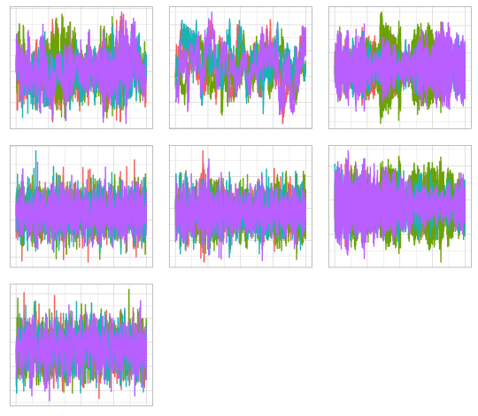

Sample Traces

```r
prep_tibble <- function(samples) {
  as_tibble(samples,
            .name_repair = ~ c("chain_1", "chain_2", "chain_3", "chain_4")) %>%
    add_column(sample = 1:n_steps) %>%
    gather(key = "chain", value = "value",-sample)
}

plot_trace <- function(samples) {
  prep_tibble(samples) %>%
    ggplot(aes(x = sample, y = value, color = chain)) +
    geom_line() +
    theme_light() +
    theme(
      legend.position = "none",
      axis.title = element_blank(),
      axis.text = element_blank(),
      axis.ticks = element_blank()
    )
}

plot_traces <- function(samples) {
  plots <- purrr::map(samples, plot_trace)
  do.call(grid.arrange, plots)
}

plot_traces(samples)
```

Now for a synopsis of posterior parameter statistics, including the usual per-parameter sampling indicators effective sample size and rhat.

```r
all_samples <- map(samples, as.vector)

means <- map_dbl(all_samples, mean)

sds <- map_dbl(all_samples, sd)

hpdis <- map(all_samples, ~ hdi(.x) %>% t() %>% as_tibble())

summary <- tibble(
  mean = means,
  sd = sds,
  hpdi = hpdis
) %>% unnest() %>%
  add_column(param = colnames(df_c), .after = FALSE) %>%
  add_column(
    n_effective = effective_sample_size,
    rhat = potential_scale_reduction
  )
```

| param | mean | sd | lower | upper | n_effective | rhat |
| --- | --- | --- | --- | --- | --- | --- |
| intercept | 4.053035 | 0.0151787 | 4.024162 | 4.0831909 | 505.46570 | 1.678775 |
| depends | 1.322970 | 0.0592539 | 1.209526 | 1.4228699 | 11.18595 | 2.933664 |
| imports | 2.895995 | 0.1113399 | 2.675557 | 3.1045258 | 1000.00000 | 1.012346 |
| doc_size | 6.187785 | 0.3900252 | 5.460509 | 6.9723330 | 1000.00000 | 1.000596 |
| r_size | 2.937681 | 0.2468468 | 2.480897 | 3.4290159 | 1000.00000 | 1.000331 |
| ns_import | 1.534855 | 0.2197282 | 1.142424 | 1.9546677 | 1000.00000 | 1.000320 |
| ns_export | -0.285461 | 0.6472537 | -1.618419 | 0.9485365 | 585.98348 | 1.002385 |

| term | estimate | std.error | statistic | p.value | conf.low | conf.high |
| --- | --- | --- | --- | --- | --- | --- |
| (Intercept) | 4.0501073 | 0.0173255 | 233.765295 | 0.0000000 | NA | NA |
| depends | 0.1084396 | 0.0069786 | 15.538848 | 0.0000000 | NA | NA |
| imports | 0.0661328 | 0.0032742 | 20.198104 | 0.0000000 | NA | NA |
| doc_size | 7.1396410 | 0.5227058 | 13.659004 | 0.0000000 | NA | NA |
| r_size | 0.8436546 | 0.0888331 | 9.497079 | 0.0000000 | NA | NA |
| ns_import | 0.0055308 | 0.0010317 | 5.361023 | 0.0000001 | NA | NA |
| ns_export | -0.0004734 | 0.0003772 | -1.254921 | 0.2095073 | NA | NA |

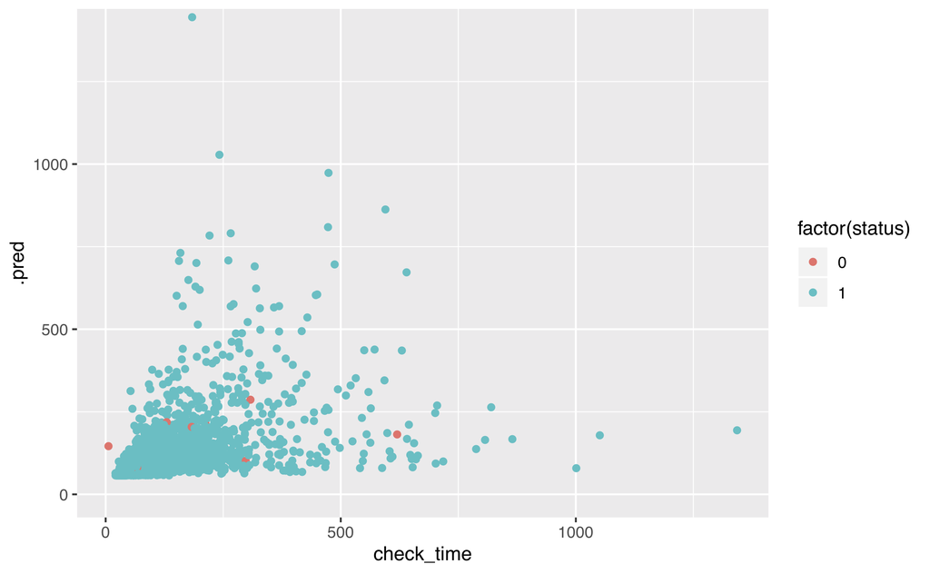

Survival Regression Prediction

```r
train_test_split <- initial_split(check_times, strata = "status")
check_time_train <- training(train_test_split)
check_time_test <- testing(train_test_split)

survreg_fit <-
  surv_reg(dist = "exponential") %>%
  set_engine("survival") %>%
  fit(Surv(check_time, status) ~ depends + imports + doc_size + r_size +
        ns_import + ns_export,
      data = check_time_train)
tidy(survreg_fit)
survreg_pred <-
  predict(survreg_fit, check_time_test) %>%
  bind_cols(check_time_test %>% select(check_time, status))

ggplot(survreg_pred, aes(x = check_time, y = .pred, color = factor(status))) +
  geom_point() +
  coord_cartesian(ylim = c(0, 1400))
```

For the MCMC model, we re-train on just the training set and obtain the parameter summary. The code is analogous to the above and not shown here.

We can now predict on the test set, for simplicity just using the posterior means:

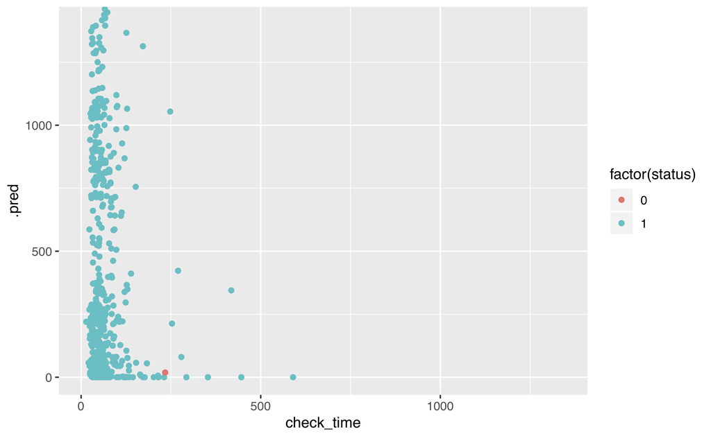

```r
df2 <- check_time_test %>% select(
                    depends,
                    imports,
                    doc_size,
                    r_size,
                    ns_import,
                    ns_export) %>%
  add_column(intercept = rep(1, nrow(check_time_test)), .before = 1)

mcmc_pred <- df2 %>% as.matrix() %*% summary$mean %>% exp() %>% as.numeric()
mcmc_pred <- check_time_test %>% select(check_time, status) %>%
  add_column(.pred = mcmc_pred)

ggplot(mcmc_pred, aes(x = check_time, y = .pred, color = factor(status))) +
  geom_point() +
  coord_cartesian(ylim = c(0, 1400))
```

# Question 2.

Make your own tweaks. For example, try different tuning parameter values and report what you found, or try a new data set, or apply the method to a new application.

## The model

```r
library(keras)
use_implementation("tensorflow")
model <- function(data) {
  tfd_joint_distribution_sequential(
    list(
      tfd_sample_distribution(tfd_normal(0, 1), sample_shape = 7),
      function(betas)
        tfd_independent(
          tfd_exponential(
            rate = 1 / tf$math$exp(tf$transpose(
              tf$matmul(tf$cast(data, betas$dtype), tf$transpose(betas))))),
          reinterpreted_batch_ndims = 1)))
}
m <- model(df_nc %>% as.matrix())
```

Always, we test if samples from that model have the expected shapes:

```r
samples <- m %>% tfd_sample(4)
```

How likely are these samples?

```r
m %>% tfd_log_prob(samples)
```

The next thing to do is define the target we want to optimize.

## Optimization Target

```r
get_exponential_lccdf <- function(betas, data, target) {
  e <-  tfd_independent(tfd_exponential(rate = 1 / tf$math$exp(tf$transpose(tf$matmul(
    tf$cast(data, betas$dtype), tf$transpose(betas)
  )))),
  reinterpreted_batch_ndims = 1)
  cum_prob <- e %>% tfd_cdf(tf$cast(target, betas$dtype))
  tf$math$log(1 - cum_prob)
}

get_log_prob <-
  function(target_nc,
           censored_data = NULL,
           target_c = NULL) {
    log_prob <- function(betas) {
      log_prob <-
        m %>% tfd_log_prob(list(betas, tf$cast(target_nc, betas$dtype)))
      potential <-
        if (!is.null(censored_data) && !is.null(target_c))
          get_exponential_lccdf(betas, censored_data, target_c)
      else
        0
      log_prob + potential
    }
    log_prob
  }

log_prob <-
  get_log_prob(
    check_time_nc %>% tf$transpose(),
    df_c %>% as.matrix(),
    check_time_c %>% tf$transpose()
  )
```

## Sampling

The original settings are *n_chains = 4, n_burnin = 1000, n_steps = 1000*, I changed *n_steps* to 5000. *mcmc_hamiltonian_monte_carlo* function has two parameters, *num_leapfrog_steps*, *step_size*, the original settings are *num_leapfrog_steps = 64*, *step_size = 0.1*, I changed these two parameters to *num_leapfrog_steps = 32*, *step_size = 0.05*

```r
n_chains <- 4
n_burnin <- 1000
n_steps <- 5000

# keep track of some diagnostic output, acceptance and step size
trace_fn <- function(state, pkr) {
  list(
    pkr$inner_results$is_accepted,
    pkr$inner_results$accepted_results$step_size
  )
}

# get shape of initial values
# to start sampling without producing NaNs, we will feed the algorithm
# tf$zeros_like(initial_betas)
# instead
initial_betas <- (m %>% tfd_sample(n_chains))[[1]]

hmc <- mcmc_hamiltonian_monte_carlo(
  target_log_prob_fn = log_prob,
  num_leapfrog_steps = 32,
  step_size = 0.05
) %>%
  mcmc_simple_step_size_adaptation(target_accept_prob = 0.8,
                                   num_adaptation_steps = n_burnin)

run_mcmc <- function(kernel) {
  kernel %>% mcmc_sample_chain(
    num_results = n_steps,
    num_burnin_steps = n_burnin,
    current_state = tf$ones_like(initial_betas),
    trace_fn = trace_fn
  )
}

# important for performance: run HMC in graph mode
run_mcmc <- tf_function(run_mcmc)

res <- hmc %>% run_mcmc()
samples <- res$all_states
```

## Results

```r
accepted <- res$trace[[1]]
as.numeric(accepted) %>% mean()

step_size <- res$trace[[2]]
as.numeric(step_size) %>% mean()

effective_sample_size <- mcmc_effective_sample_size(samples) %>%
  as.matrix() %>%
  apply(2, mean)
potential_scale_reduction <- mcmc_potential_scale_reduction(samples) %>%
  as.numeric()

# 2-item list, where each item has dim (1000, 4)
samples <- as.array(samples) %>% array_branch(margin = 3)
```

How well did the sampling work? The chains mix well, but for some parameters, autocorrelation is still pretty high.

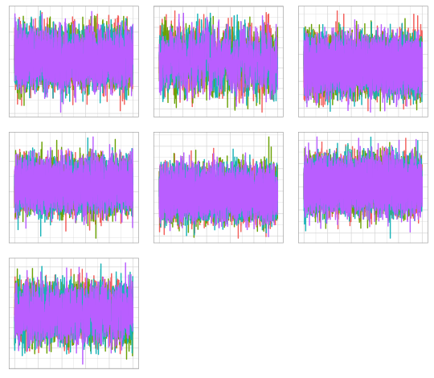

```r
prep_tibble <- function(samples) {
  as_tibble(samples,
            .name_repair = ~ c("chain_1", "chain_2", "chain_3", "chain_4")) %>%
    add_column(sample = 1:n_steps) %>%
    gather(key = "chain", value = "value",-sample)
}

plot_trace <- function(samples) {
  prep_tibble(samples) %>%
    ggplot(aes(x = sample, y = value, color = chain)) +
    geom_line() +
    theme_light() +
    theme(
      legend.position = "none",
      axis.title = element_blank(),
      axis.text = element_blank(),
      axis.ticks = element_blank()
    )
}

plot_traces <- function(samples) {
  plots <- purrr::map(samples, plot_trace)
  do.call(grid.arrange, plots)
}

plot_traces(samples)
```

Now for a synopsis of posterior parameter statistics, including the usual per-parameter sampling indicators effective sample size and rhat.

```r
all_samples <- map(samples, as.vector)

means <- map_dbl(all_samples, mean)

sds <- map_dbl(all_samples, sd)

hpdis <- map(all_samples, ~ hdi(.x) %>% t() %>% as_tibble())

summary <- tibble(
  mean = means,
  sd = sds,
  hpdi = hpdis
) %>% unnest() %>%
  add_column(param = colnames(df_c), .after = FALSE) %>%
  add_column(
    n_effective = effective_sample_size,
    rhat = potential_scale_reduction
  )
```

| param | mean | sd | lower | upper | n_effective | rhat |
| --- | --- | --- | --- | --- | --- | --- |
| intercept | 4.0506994 | 0.0148656 | 4.0204830 | 4.0784674 | 769.8410 | 1.002124 |
| depends | 1.3351097 | 0.0718446 | 1.1961687 | 1.4737661 | 205.7616 | 1.004382 |
| imports | 2.8952633 | 0.1206736 | 2.6602232 | 3.1298945 | 3358.1371 | 1.000266 |
| doc_size | 6.1932442 | 0.3914610 | 5.4117284 | 6.9520912 | 1765.5938 | 1.000821 |
| r_size | 2.9382248 | 0.2641966 | 2.4311533 | 3.4603186 | 3021.2117 | 1.000925 |
| ns_import | 1.5311325 | 0.2679571 | 0.9979945 | 2.0496385 | 3751.1504 | 1.000173 |
| ns_export | -0.2748851 | 0.6585261 | -1.5579400 | 0.9906061 | 527.8934 | 1.004608 |

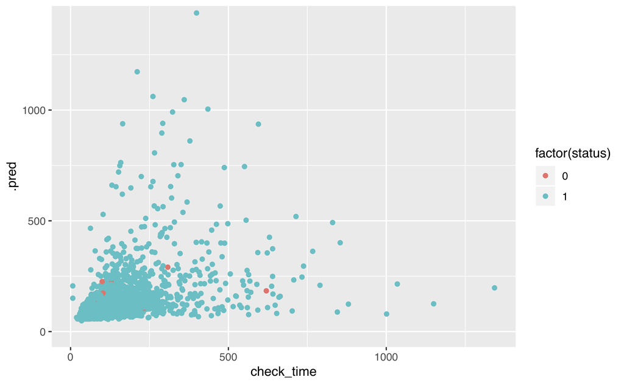

Survival Regression Prediction

| term | estimate | std.error | statistic | p.value | conf.low | conf.high |
| --- | --- | --- | --- | --- | --- | --- |
| (Intercept) | 4.0489160 | 0.0173197 | 233.7757739 | 0.0000000 | NA | NA |
| depends | 0.1074207 | 0.0069749 | 15.4010643 | 0.0000000 | NA | NA |
| imports | 0.0683266 | 0.0032972 | 20.7224691 | 0.0000000 | NA | NA |
| doc_size | 7.7812967 | 0.5421048 | 14.3538605 | 0.0000000 | NA | NA |
| r_size | 0.8460899 | 0.0875826 | 9.6604792 | 0.0000000 | NA | NA |
| ns_import | 0.0040968 | 0.0010262 | 3.9920965 | 0.0000655 | NA | NA |
| ns_export | -0.0002802 | 0.0003652 | -0.7672787 | 0.4429158 | NA | NA |

```r
train_test_split <- initial_split(check_times, strata = "status")
check_time_train <- training(train_test_split)
check_time_test <- testing(train_test_split)

survreg_fit <-
  surv_reg(dist = "exponential") %>%
  set_engine("survival") %>%
  fit(Surv(check_time, status) ~ depends + imports + doc_size + r_size +
        ns_import + ns_export,
      data = check_time_train)

tidy(survreg_fit)
survreg_pred <-
  predict(survreg_fit, check_time_test) %>%
  bind_cols(check_time_test %>% select(check_time, status))

ggplot(survreg_pred, aes(x = check_time, y = .pred, color = factor(status))) +
  geom_point() +
  coord_cartesian(ylim = c(0, 1400))
```

For the MCMC model, we re-train on just the training set and obtain the parameter summary. The code is analogous to the above and not shown here.

We can now predict on the test set, for simplicity just using the posterior means:

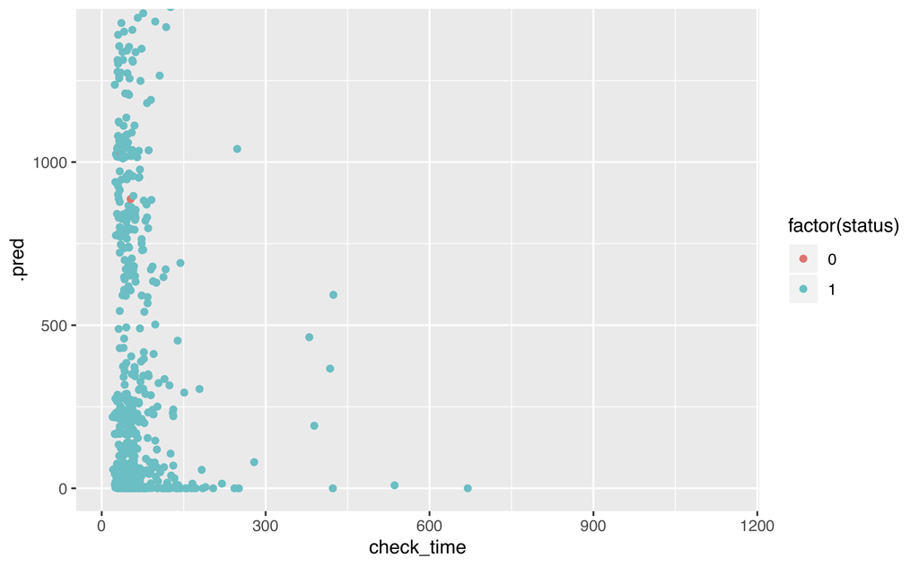

```r
df2 <- check_time_test %>% select(
                    depends,
                    imports,
                    doc_size,
                    r_size,
                    ns_import,
                    ns_export) %>%
  add_column(intercept = rep(1, nrow(check_time_test)), .before = 1)

mcmc_pred <- df2 %>% as.matrix() %*% summary$mean %>% exp() %>% as.numeric()
mcmc_pred <- check_time_test %>% select(check_time, status) %>%
  add_column(.pred = mcmc_pred)

ggplot(mcmc_pred, aes(x = check_time, y = .pred, color = factor(status))) +
  geom_point() +
  coord_cartesian(ylim = c(0, 1400))
```